# Module 1: Stock Assessment Fundamentals & Concepts

Somali Fish Stock Training

Author

Fisheries Management Team

Published

December 10, 2025

```r
require(sf)
require(tidyverse)
require(sizeMat)
require(gt)
require(tidyplots)
require(patchwork)
require(leaflet)
```

## Welcome to Module 1

**Stock Assessment Fundamentals & Concepts**

### Learning Objectives

- Understand core stock assessment principles
- Identify different data types used in assessments
- Apply concepts to real Somali fisheries data
- Build foundation for advanced methods

### Why This Matters

- Essential for evidence-based management
- Reinforces foundational knowledge
- Prepares for data-limited methods
- Supports sustainable fisheries

## What is Stock Assessment?

Stock assessment is the **scientific process** of estimating the status and productivity of fish populations to inform management decisions.

### Key Components:

- **Population Dynamics**: How fish populations change over time
- **Catch Data**: What we remove from the stock
- **Biological Data**: Growth, reproduction, mortality
- **Environmental Context**: Habitat and external factors

## The Assessment Cycle

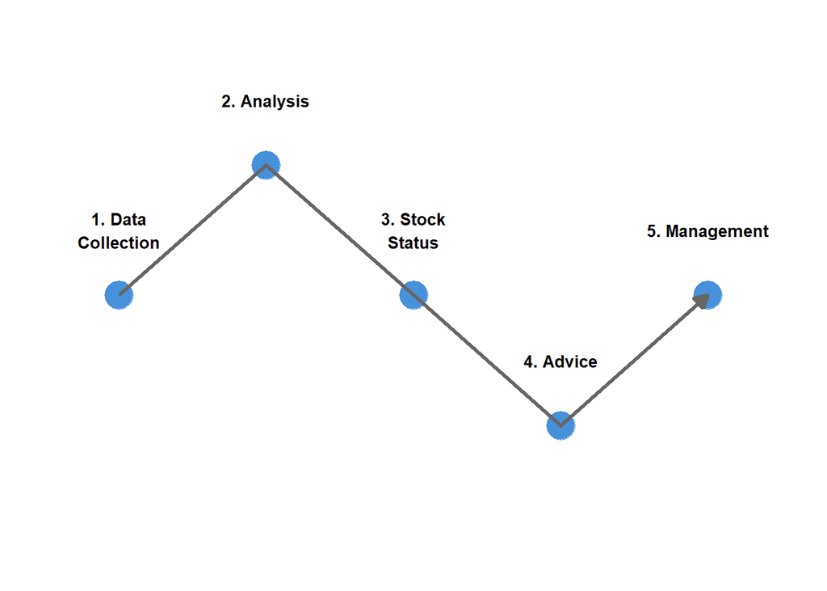

## Types of Data in Stock Assessment

### Primary Data Categories:

**Catch Data** - Total landings (numbers or weight) - Species composition - Temporal patterns - Geographic distribution

**Biological Data** - Size distributions - Age/length structure - Growth rates - Maturity information

## Types of Data (continued)

**Effort Data** - Number of vessels/fishers - Fishing days - Landing site activity - Spatial distribution

**Environmental Data** - Oceanographic conditions - Habitat quality - Seasonal patterns - Climate factors

## Case Study: Somali Fisheries Data

### What We Have in Our Dataset:

- **Landing records**: 3,571 specimens across 6 regions
- **Species groups**: Tuna, Mackerel, Shark, Jacks, Billfish, Rays & Skates
- **Time series**: 2017-2023 (7 years of data)
- **Biological measurements**: Length (cm) and Weight (kg)
- **Geographic coverage**: Berbera, Borama, Mogadishu, Kismayo, Baidoa, Galkacyo

## Key Indicators from Our Data

### CPUE (Catch Per Unit Effort)

Specimens caught per landing site per year

**What it tells us:** - Stock abundance trends - Fishing pressure changes - Sustainability signals

**Warning signs:** - ⚠️ Declining CPUE = potential overfishing - ✓ Stable CPUE = sustainable harvest

## Key Indicators: Size Structure

### Average Fish Size Trends

- **Healthy stocks**: Stable or increasing average size
- **Overfished stocks**: Declining average size over time
- **Young populations**: Smaller specimens dominate
- **Mature populations**: Mix of sizes present

### Why Size Matters:

Smaller fish = fewer breeding adults = recruitment problems

## Key Indicators: Species Diversity

### Shannon Diversity Index

Measures ecosystem stability:

**High Diversity** - Many species equally represented - Ecosystem resilience - Lower collapse risk - Adaptable to changes

**Low Diversity** - Few dominant species - Ecosystem vulnerability - High collapse risk - Susceptible to shifts

## Key Indicators: Seasonal Patterns

### Why Seasonality Matters:

- **Peak seasons**: When stocks are most vulnerable
- **Off-season monitoring**: Essential for baseline data
- **Breeding seasons**: Critical conservation periods
- **Nomadic patterns**: Species movement and migration

### Somalia’s Monsoon Seasons:

- **NEM (Nov-May)**: Northeast Monsoon
- **SEM (Jun-Sep)**: Southwest Monsoon

## Stock Status Assessment Framework

### Traffic Light System:

**Green** ✓ - CPUE stable - Size structure healthy - High diversity - Sustainable

**Yellow** ⚠️ - CPUE declining - Size shrinking - Diversity moderate - Caution needed

**Red** ✗ - CPUE low - Size very small - Low diversity - Urgent action

## Data Quality Matters

### Good Data Requires:

**Collection Standards** - Consistent methods - Regular sampling - Complete records - Training & protocols

**Quality Control** - Data verification - Error detection - Outlier assessment - Metadata documentation

## Decision-Making Framework

### From Data to Decisions:

[figure not shown]

## Next Steps

### Transition to Module 2:

- **Module 1**: ✓ Concepts established
- **Module 2**: Data collection protocols & sampling design
- **Module 3**: Data-limited assessment methods

## Questions & Discussion

### Let’s Explore:

- What surprises you about the data?
- Which indicators seem most important?
- How would you communicate these findings?
- What additional data would help?

## References & Resources

### Key Concepts:

- FAO Stock Assessment: https://www.fao.org/fishery/
- R for Fisheries: https://www.afsc.noaa.gov/
- Data-limited Methods: Costello et al., 2012

### Somali Context:

- Somalia Fisheries Profile
- Indian Ocean Tuna Commission (IOTC)
- Regional fisheries management bodies

## Thank You

**Somali Fish Stock Training**

Module 1: Fundamentals & Concepts

*Building capacity for evidence-based fisheries management*

Questions? Contact the training team.